# hw8

Austin Melendez

2026-04-09

Section 8.4: Exercises 1, 4, 5

```r
#install.packages("ISLR2")
#install.package("tree")

library(ISLR2)
library(tree)
```

## Exercise 1

Draw an example of a partition of two-dimensional feature space that could result from recursive binary splitting. Your example should contain at least six regions. Draw a decision tree corresponding to this partition. Be sure to label all aspects of your figures, including regions $R_1$, $R_2$, …, the cut points $t_1$, $t_2$, …, and so forth.

I used Google and AI to help me create the below visualization in R after sketching it in my notebook.

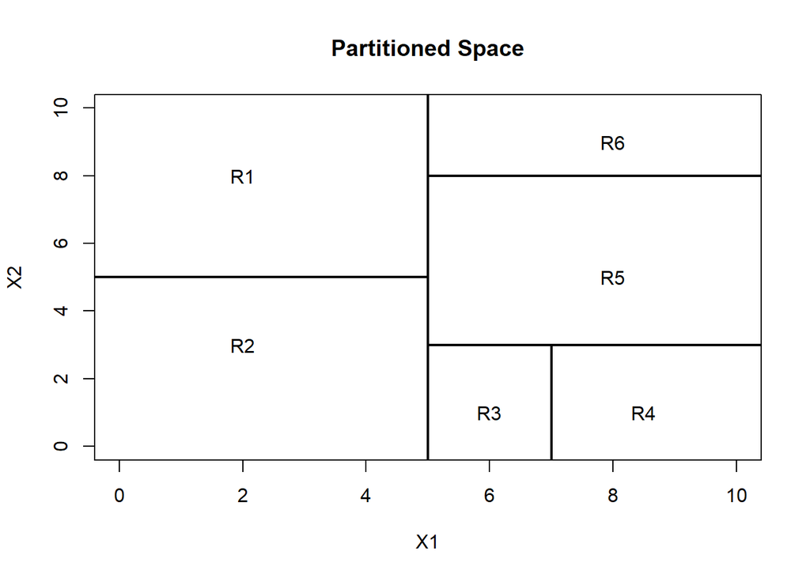

```r
plot(0:10, 0:10, type="n", xlab="X1", ylab="X2", main="Partitioned Space")

# Splits
abline(v=5, lwd=2)       # t1
segments(-1,5,5,5,lwd=2) # t2
segments(5,8,11,8,lwd=2) # t3
segments(5,3,11,3,lwd=2) # t4
segments(7,-1,7,3,lwd=2) # t5

# Labels
text(2,8,"R1")
text(2,3,"R2")
text(6,1,"R3")
text(8.5,1,"R4")
text(8,5,"R5")
text(8,9,"R6")
```

## Exercise 4

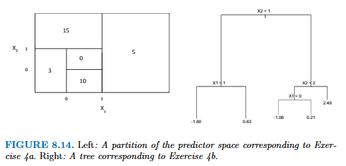

Textbook Figure 8.14

### A

Sketch the tree corresponding to the partition of the predictor space illustrated in the left-hand panel of `Figure 8.14`. The numbers inside the boxes indicate the mean of $Y$ within each region.

I tried to use Google and AI to help me create the below visualization in R after sketching it in my notebook, but it was just easier to attach a picture of my drawing.

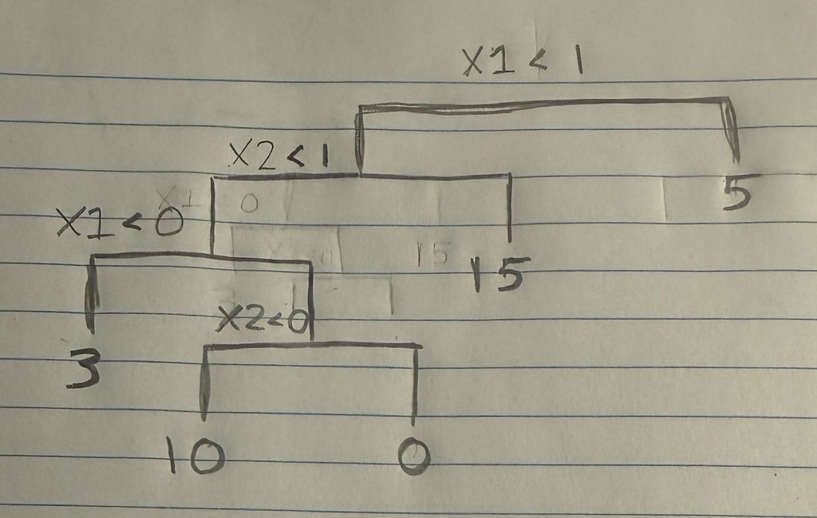

Figure 8.14 Exercise 4A

### B

Create a diagram similar to the left-hand panel of `Figure 8.14`, using the tree illustrated in the right-hand panel of the same figure. You should divide up the predictor space into the correct regions and indicate the mean for each region.

I tried to use Google and AI to help me create the below visualization in R after sketching it in my notebook, but it was just easier to attach a picture of my drawing.

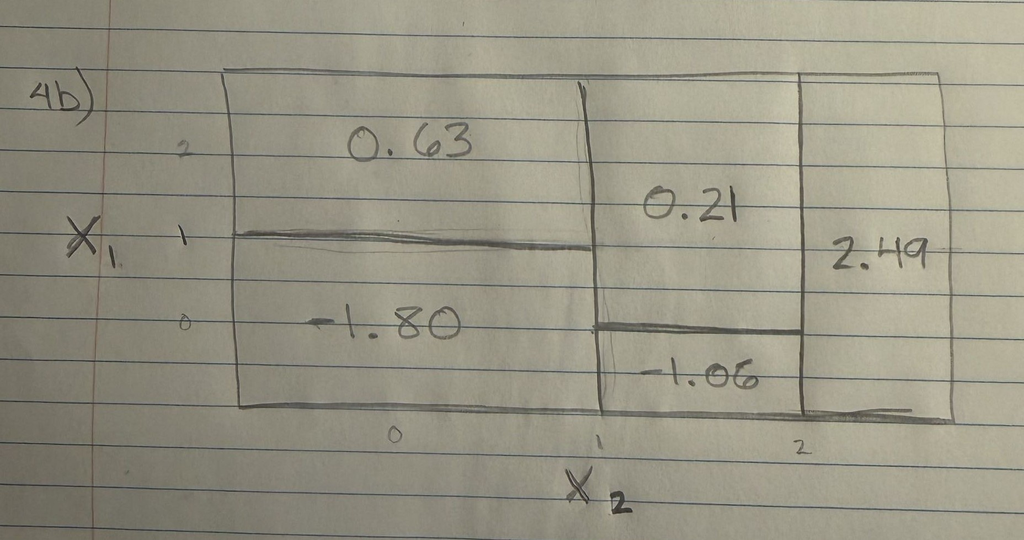

Figure 8.14 Exercise 4B

## Exercise 5

Suppose we produce ten bootstrapped samples from a data set containing red and green classes. We then apply a classification tree to each bootstrapped sample and, for a specific value of $X$, produce 10 estimates of $P(Red | X)$:

$$0.1, 0.15, 0.2, 0.2, 0.55, 0.6, 0.6,
0.65, 0.7, and \space 0.75$$

There are two common ways to combine these results together into a single class prediction. One is the majority vote approach discussed in this chapter. The second approach is to classify based on the average probability. In this example, what is the final classification under each of these two approaches?

### A)

Majority Vote We can classify:
$$Red
\space if \space P > 0.5$$
$$Green
\space if \space P \leq 0.5$$

Therefore:
$$Green: 0.1, 0.15, 0.2, 0.2
\space (4 \space results)$$
$$Red:
0.55, 0.6, 0.6, 0.65, 0.7, 0.75 \space (6 \space results)$$

Since $Red$ has more results, Majority Vote says we should classify this as $Red$.

### B)

Average Probability

```r
probs <- c(0.1,0.15,0.2,0.2,0.55,0.6,0.6,0.65,0.7,0.75)
mean(probs)
```

```
## [1] 0.45
```

Since our mean $\approx 0.45$, average probability says we should classify this as $Green$.